# DBnomics R client

Sébastien Galais[^1], Thomas Brand[^2]

# 1 DBnomics: the world’s economic database

[figure not shown]

# 2 Fetch time series by `ids`

First, let’s assume that we know which series we want to download. A series identifier (`ids`) is defined by three values, formatted like this: `provider_code`/`dataset_code`/`series_code`.

## 2.1 Fetch one series from dataset ‘Unemployment rate’ (ZUTN) of AMECO provider

```r
library(data.table)
library(rdbnomics)
```

```r
df <- rdb(ids = "AMECO/ZUTN/EA19.1.0.0.0.ZUTN")
df <- df[!is.na(value)]
```

In such `data.table`, you will always find at least ten columns:

- `provider_code`
- `dataset_code`
- `dataset_name`
- `series_code`
- `series_name`
- `original_period` (character string)
- `period` (date of the first day of `original_period`)
- `original_value` (character string)
- `value`
- `@frequency` (harmonized frequency generated by DBnomics)

The other columns depend on the provider and on the dataset. They always come in pairs (for the code and the name). In the data.frame `df`, you have:

- `unit` (code) and `Unit` (name)
- `geo` (code) and `Country` (name)
- `freq` (code) and `Frequency` (name)

```
##    provider_code dataset_code        dataset_name         series_code
## 1:         AMECO         ZUTN Unemployment rat... EA19.1.0.0.0.ZUT...
## 2:         AMECO         ZUTN Unemployment rat... EA19.1.0.0.0.ZUT...
## 3:         AMECO         ZUTN Unemployment rat... EA19.1.0.0.0.ZUT...
## 4:         AMECO         ZUTN Unemployment rat... EA19.1.0.0.0.ZUT...
## 5:         AMECO         ZUTN Unemployment rat... EA19.1.0.0.0.ZUT...
## 6:         AMECO         ZUTN Unemployment rat... EA19.1.0.0.0.ZUT...
##            series_name original_period     period original_value value
## 1: Annually – (Perc...            1998 1998-01-01           10.4  10.4
## 2: Annually – (Perc...            1999 1999-01-01            9.7   9.7
## 3: Annually – (Perc...            2000 2000-01-01            8.9   8.9
## 4: Annually – (Perc...            2001 2001-01-01            8.3   8.3
## 5: Annually – (Perc...            2002 2002-01-01            8.6   8.6
## 6: Annually – (Perc...            2003 2003-01-01            9.1   9.1
##    @frequency                unit                Unit  geo   Country freq
## 1:     annual percentage-of-ac... (Percentage of a... ea19 Euro area    a
## 2:     annual percentage-of-ac... (Percentage of a... ea19 Euro area    a
## 3:     annual percentage-of-ac... (Percentage of a... ea19 Euro area    a
## 4:     annual percentage-of-ac... (Percentage of a... ea19 Euro area    a
## 5:     annual percentage-of-ac... (Percentage of a... ea19 Euro area    a
## 6:     annual percentage-of-ac... (Percentage of a... ea19 Euro area    a
##    Frequency          indexed_at
## 1:  Annually 2019-11-08 16:33:50
## 2:  Annually 2019-11-08 16:33:50
## 3:  Annually 2019-11-08 16:33:50
## 4:  Annually 2019-11-08 16:33:50
## 5:  Annually 2019-11-08 16:33:50
## 6:  Annually 2019-11-08 16:33:50
```

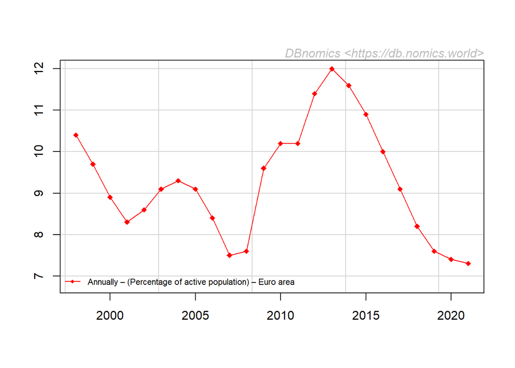

In the event that you only use the argument `ids`, you can drop it and run:

```r
df <- rdb("AMECO/ZUTN/EA19.1.0.0.0.ZUTN")
```

## 2.2 Fetch two series from dataset ‘Unemployment rate’ (ZUTN) of AMECO provider

```r
df <- rdb(ids = c("AMECO/ZUTN/EA19.1.0.0.0.ZUTN", "AMECO/ZUTN/DNK.1.0.0.0.ZUTN"))
df <- df[!is.na(value)]
```

```
##    provider_code dataset_code        dataset_name      series_code
## 1:         AMECO         ZUTN Unemployment rat... DNK.1.0.0.0.ZUTN
## 2:         AMECO         ZUTN Unemployment rat... DNK.1.0.0.0.ZUTN
## 3:         AMECO         ZUTN Unemployment rat... DNK.1.0.0.0.ZUTN
## 4:         AMECO         ZUTN Unemployment rat... DNK.1.0.0.0.ZUTN
## 5:         AMECO         ZUTN Unemployment rat... DNK.1.0.0.0.ZUTN
## 6:         AMECO         ZUTN Unemployment rat... DNK.1.0.0.0.ZUTN
##            series_name original_period     period original_value value
## 1: Annually – (Perc...            1960 1960-01-01              2   2.0
## 2: Annually – (Perc...            1961 1961-01-01            1.6   1.6
## 3: Annually – (Perc...            1962 1962-01-01            1.4   1.4
## 4: Annually – (Perc...            1963 1963-01-01              2   2.0
## 5: Annually – (Perc...            1964 1964-01-01            1.2   1.2
## 6: Annually – (Perc...            1965 1965-01-01            0.9   0.9
##    @frequency                unit                Unit geo Country freq
## 1:     annual percentage-of-ac... (Percentage of a... dnk Denmark    a
## 2:     annual percentage-of-ac... (Percentage of a... dnk Denmark    a
## 3:     annual percentage-of-ac... (Percentage of a... dnk Denmark    a
## 4:     annual percentage-of-ac... (Percentage of a... dnk Denmark    a
## 5:     annual percentage-of-ac... (Percentage of a... dnk Denmark    a
## 6:     annual percentage-of-ac... (Percentage of a... dnk Denmark    a
##    Frequency          indexed_at
## 1:  Annually 2019-11-08 16:33:50
## 2:  Annually 2019-11-08 16:33:50
## 3:  Annually 2019-11-08 16:33:50
## 4:  Annually 2019-11-08 16:33:50
## 5:  Annually 2019-11-08 16:33:50
## 6:  Annually 2019-11-08 16:33:50
```

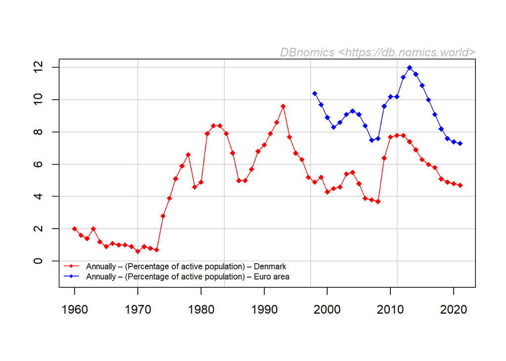

## 2.3 Fetch two series from different datasets of different providers

```r
df <- rdb(ids = c("AMECO/ZUTN/EA19.1.0.0.0.ZUTN", "Eurostat/une_rt_q/Q.SA.Y15-24.PC_ACT.T.EA19"))
df <- df[!is.na(value)]
```

```
##    provider_code dataset_code        dataset_name         series_code
## 1:         AMECO         ZUTN Unemployment rat... EA19.1.0.0.0.ZUT...
## 2:         AMECO         ZUTN Unemployment rat... EA19.1.0.0.0.ZUT...
## 3:         AMECO         ZUTN Unemployment rat... EA19.1.0.0.0.ZUT...
## 4:         AMECO         ZUTN Unemployment rat... EA19.1.0.0.0.ZUT...
## 5:         AMECO         ZUTN Unemployment rat... EA19.1.0.0.0.ZUT...
## 6:         AMECO         ZUTN Unemployment rat... EA19.1.0.0.0.ZUT...
##            series_name original_period     period original_value value
## 1: Annually – (Perc...            1997 1997-01-01           11.5  11.5
## 2: Annually – (Perc...            1998 1998-01-01             11  11.0
## 3: Annually – (Perc...            1999 1999-01-01           10.2  10.2
## 4: Annually – (Perc...            2000 2000-01-01            9.2   9.2
## 5: Annually – (Perc...            2001 2001-01-01            8.4   8.4
## 6: Annually – (Perc...            2002 2002-01-01            8.6   8.6
##    @frequency                unit Unit  geo Country freq Frequency age
```

[output cut: 20 more lines]

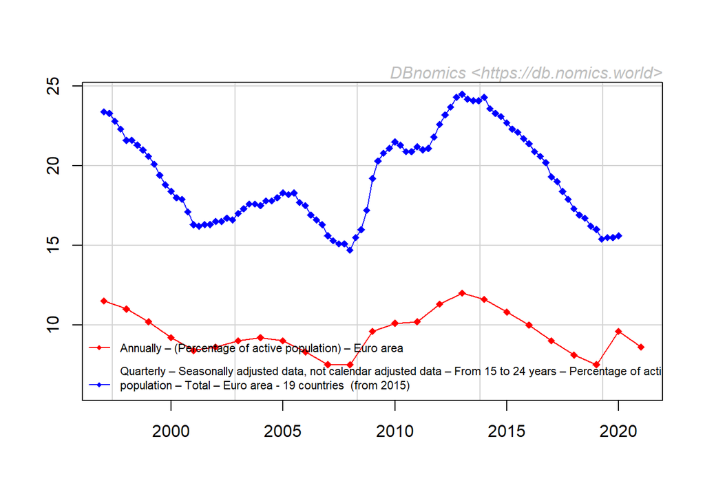

# 3 Fetch time series by `mask`

The code mask notation is a very concise way to select one or many time series at once.

## 3.1 Fetch one series from dataset ‘Balance of Payments’ (BOP) of IMF

```r
df <- rdb("IMF", "BOP", mask = "A.FR.BCA_BP6_EUR")
df <- df[!is.na(value)]
```

```
##    provider_code dataset_code        dataset_name      series_code
## 1:           IMF          BOP Balance of Payme... A.FR.BCA_BP6_EUR
## 2:           IMF          BOP Balance of Payme... A.FR.BCA_BP6_EUR
## 3:           IMF          BOP Balance of Payme... A.FR.BCA_BP6_EUR
## 4:           IMF          BOP Balance of Payme... A.FR.BCA_BP6_EUR
## 5:           IMF          BOP Balance of Payme... A.FR.BCA_BP6_EUR
## 6:           IMF          BOP Balance of Payme... A.FR.BCA_BP6_EUR
##            series_name original_period     period original_value     value
## 1: Annual – France ...            1999 1999-01-01      47672.847 47672.847
## 2: Annual – France ...            2000 2000-01-01      17550.669 17550.669
## 3: Annual – France ...            2001 2001-01-01      23278.392 23278.392
## 4: Annual – France ...            2002 2002-01-01      18718.406 18718.406
## 5: Annual – France ...            2003 2003-01-01      14195.493 14195.493
## 6: Annual – France ...            2004 2004-01-01       7520.754  7520.754
##    @frequency FREQ Frequency          indexed_at           Indicator
## 1:     annual    A    Annual 2020-03-26 20:10:01 Current Account,...
## 2:     annual    A    Annual 2020-03-26 20:10:01 Current Account,...
## 3:     annual    A    Annual 2020-03-26 20:10:01 Current Account,...
## 4:     annual    A    Annual 2020-03-26 20:10:01 Current Account,...
## 5:     annual    A    Annual 2020-03-26 20:10:01 Current Account,...
## 6:     annual    A    Annual 2020-03-26 20:10:01 Current Account,...
##      INDICATOR observations_attributes REF_AREA Reference Area
## 1: BCA_BP6_EUR          OFFICIAL_BPM,K       FR         France
## 2: BCA_BP6_EUR           OFFICIAL_BPM,       FR         France
## 3: BCA_BP6_EUR           OFFICIAL_BPM,       FR         France
## 4: BCA_BP6_EUR           OFFICIAL_BPM,       FR         France
## 5: BCA_BP6_EUR           OFFICIAL_BPM,       FR         France
## 6: BCA_BP6_EUR           OFFICIAL_BPM,       FR         France
```

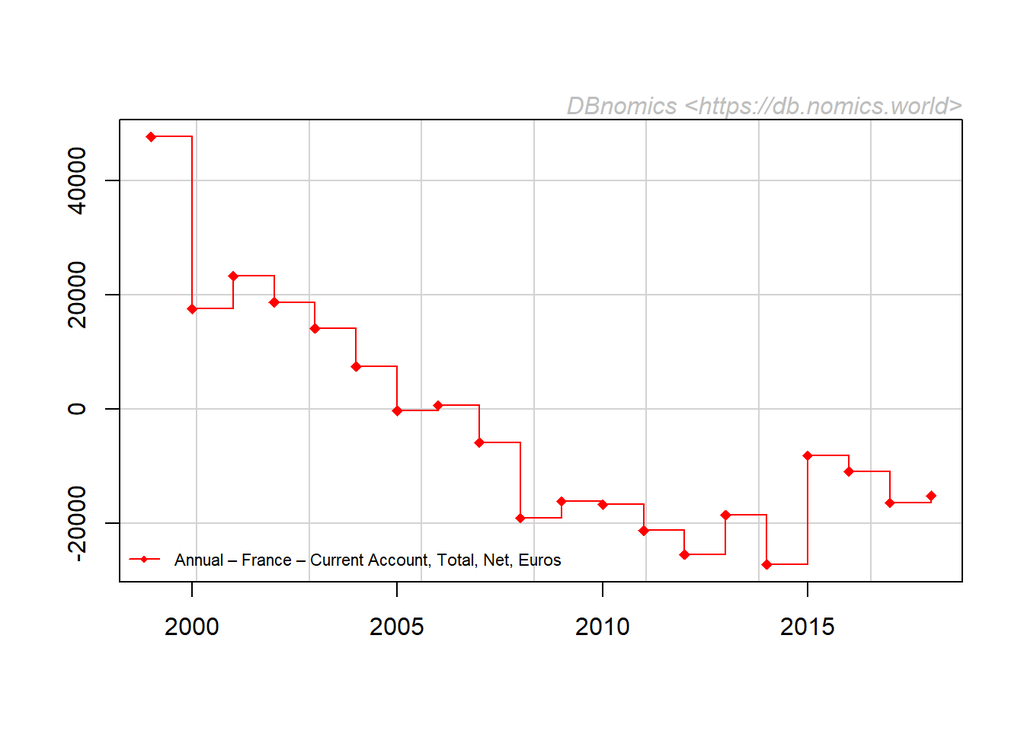

In the event that you only use the arguments `provider_code`, `dataset_code` and `mask`, you can drop the name `mask` and run:

```r
df <- rdb("IMF", "BOP", "A.FR.BCA_BP6_EUR")
```

## 3.2 Fetch two series from dataset ‘Balance of Payments’ (BOP) of IMF

You just have to add a `+` between two different values of a dimension.

```r
df <- rdb("IMF", "BOP", mask = "A.FR+ES.BCA_BP6_EUR")
df <- df[!is.na(value)]
```

```
##    provider_code dataset_code        dataset_name      series_code
## 1:           IMF          BOP Balance of Payme... A.ES.BCA_BP6_EUR
## 2:           IMF          BOP Balance of Payme... A.ES.BCA_BP6_EUR
## 3:           IMF          BOP Balance of Payme... A.ES.BCA_BP6_EUR
## 4:           IMF          BOP Balance of Payme... A.ES.BCA_BP6_EUR
## 5:           IMF          BOP Balance of Payme... A.ES.BCA_BP6_EUR
## 6:           IMF          BOP Balance of Payme... A.ES.BCA_BP6_EUR
##            series_name original_period     period original_value  value
## 1: Annual – Spain –...            1999 1999-01-01         -19295 -19295
## 2: Annual – Spain –...            2000 2000-01-01         -27921 -27921
## 3: Annual – Spain –...            2001 2001-01-01         -30672 -30672
## 4: Annual – Spain –...            2002 2002-01-01         -27959 -27959
## 5: Annual – Spain –...            2003 2003-01-01         -31153 -31153
## 6: Annual – Spain –...            2004 2004-01-01         -47116 -47116
##    @frequency FREQ Frequency          indexed_at           Indicator
## 1:     annual    A    Annual 2020-03-26 20:10:01 Current Account,...
## 2:     annual    A    Annual 2020-03-26 20:10:01 Current Account,...
## 3:     annual    A    Annual 2020-03-26 20:10:01 Current Account,...
## 4:     annual    A    Annual 2020-03-26 20:10:01 Current Account,...
## 5:     annual    A    Annual 2020-03-26 20:10:01 Current Account,...
## 6:     annual    A    Annual 2020-03-26 20:10:01 Current Account,...
##      INDICATOR observations_attributes REF_AREA Reference Area
## 1: BCA_BP6_EUR          OFFICIAL_BPM,K       ES          Spain
## 2: BCA_BP6_EUR           OFFICIAL_BPM,       ES          Spain
## 3: BCA_BP6_EUR           OFFICIAL_BPM,       ES          Spain
## 4: BCA_BP6_EUR           OFFICIAL_BPM,       ES          Spain
## 5: BCA_BP6_EUR           OFFICIAL_BPM,       ES          Spain
## 6: BCA_BP6_EUR           OFFICIAL_BPM,       ES          Spain
```

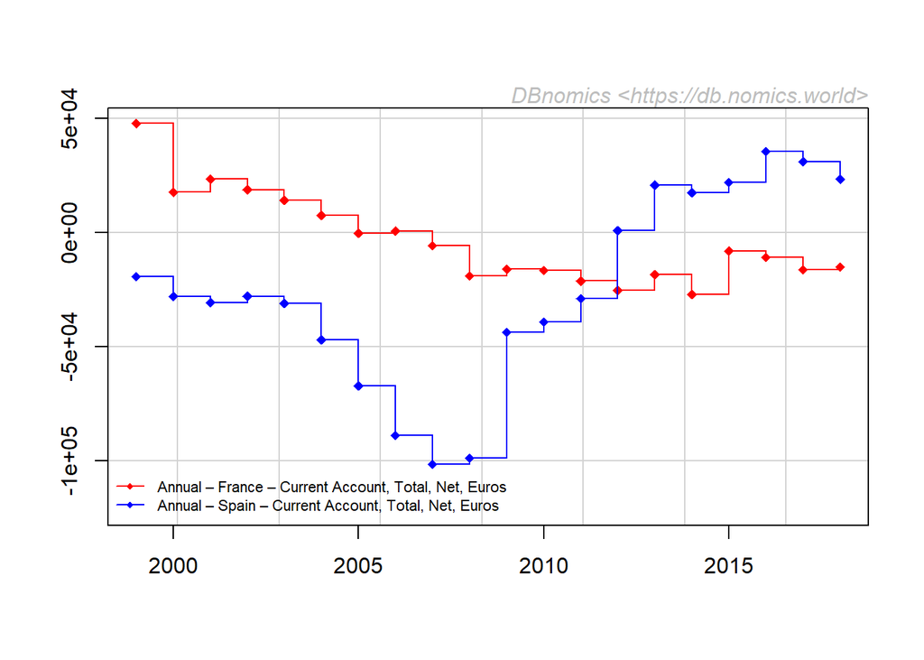

## 3.3 Fetch all series along one dimension from dataset ‘Balance of Payments’ (BOP) of IMF

```r
df <- rdb("IMF", "BOP", mask = "A..BCA_BP6_EUR")
df <- df[!is.na(value)]
df <- df[order(-period, REF_AREA)]
df <- head(df, 100)
```

```
##    provider_code dataset_code        dataset_name      series_code
## 1:           IMF          BOP Balance of Payme... A.DE.BCA_BP6_EUR
## 2:           IMF          BOP Balance of Payme... A.EE.BCA_BP6_EUR
## 3:           IMF          BOP Balance of Payme... A.LU.BCA_BP6_EUR
## 4:           IMF          BOP Balance of Payme... A.LV.BCA_BP6_EUR
## 5:           IMF          BOP Balance of Payme... A.PT.BCA_BP6_EUR
## 6:           IMF          BOP Balance of Payme... A.RS.BCA_BP6_EUR
##            series_name original_period     period original_value      value
## 1: Annual – Germany...            2019 2019-01-01         245532 245532.000
## 2: Annual – Estonia...            2019 2019-01-01        615.256    615.256
## 3: Annual – Luxembo...            2019 2019-01-01     2846.74554   2846.746
## 4: Annual – Latvia ...            2019 2019-01-01           -163   -163.000
## 5: Annual – Portuga...            2019 2019-01-01           -181   -181.000
## 6: Annual – Serbia ...            2019 2019-01-01    -3159.86552  -3159.866
##    @frequency FREQ Frequency          indexed_at           Indicator
## 1:     annual    A    Annual 2020-03-26 20:10:01 Current Account,...
## 2:     annual    A    Annual 2020-03-26 20:10:01 Current Account,...
## 3:     annual    A    Annual 2020-03-26 20:10:01 Current Account,...
## 4:     annual    A    Annual 2020-03-26 20:10:01 Current Account,...
## 5:     annual    A    Annual 2020-03-26 20:10:01 Current Account,...
## 6:     annual    A    Annual 2020-03-26 20:10:01 Current Account,...
##      INDICATOR observations_attributes REF_AREA Reference Area
## 1: BCA_BP6_EUR           OFFICIAL_BPM,       DE        Germany
## 2: BCA_BP6_EUR           OFFICIAL_BPM,       EE        Estonia
## 3: BCA_BP6_EUR           OFFICIAL_BPM,       LU     Luxembourg
## 4: BCA_BP6_EUR           OFFICIAL_BPM,       LV         Latvia
## 5: BCA_BP6_EUR           OFFICIAL_BPM,       PT       Portugal
## 6: BCA_BP6_EUR           OFFICIAL_BPM,       RS         Serbia
```

## 3.4 Fetch series along multiple dimensions from dataset ‘Balance of Payments’ (BOP) of IMF

```r
df <- rdb("IMF", "BOP", mask = "A.FR.BCA_BP6_EUR+IA_BP6_EUR")
df <- df[!is.na(value)]
df <- df[order(period), head(.SD, 50), by = INDICATOR]
```

```
##    provider_code dataset_code        dataset_name      series_code
## 1:           IMF          BOP Balance of Payme... A.FR.BCA_BP6_EUR
## 2:           IMF          BOP Balance of Payme... A.FR.BCA_BP6_EUR
## 3:           IMF          BOP Balance of Payme... A.FR.BCA_BP6_EUR
## 4:           IMF          BOP Balance of Payme... A.FR.BCA_BP6_EUR
## 5:           IMF          BOP Balance of Payme... A.FR.BCA_BP6_EUR
## 6:           IMF          BOP Balance of Payme... A.FR.BCA_BP6_EUR
##            series_name original_period     period original_value     value
## 1: Annual – France ...            1999 1999-01-01      47672.847 47672.847
## 2: Annual – France ...            2000 2000-01-01      17550.669 17550.669
## 3: Annual – France ...            2001 2001-01-01      23278.392 23278.392
## 4: Annual – France ...            2002 2002-01-01      18718.406 18718.406
## 5: Annual – France ...            2003 2003-01-01      14195.493 14195.493
## 6: Annual – France ...            2004 2004-01-01       7520.754  7520.754
##    @frequency FREQ Frequency          indexed_at           Indicator
## 1:     annual    A    Annual 2020-03-26 20:10:01 Current Account,...
## 2:     annual    A    Annual 2020-03-26 20:10:01 Current Account,...
## 3:     annual    A    Annual 2020-03-26 20:10:01 Current Account,...
## 4:     annual    A    Annual 2020-03-26 20:10:01 Current Account,...
## 5:     annual    A    Annual 2020-03-26 20:10:01 Current Account,...
## 6:     annual    A    Annual 2020-03-26 20:10:01 Current Account,...
##      INDICATOR observations_attributes REF_AREA Reference Area
## 1: BCA_BP6_EUR          OFFICIAL_BPM,K       FR         France
## 2: BCA_BP6_EUR           OFFICIAL_BPM,       FR         France
## 3: BCA_BP6_EUR           OFFICIAL_BPM,       FR         France
## 4: BCA_BP6_EUR           OFFICIAL_BPM,       FR         France
## 5: BCA_BP6_EUR           OFFICIAL_BPM,       FR         France
## 6: BCA_BP6_EUR           OFFICIAL_BPM,       FR         France
```

# 4 Fetch time series by `dimensions`

Searching by `dimensions` is a less concise way to select time series than using the code `mask`, but it works with all the different providers. You have a “*Description of series code*” at the bottom of each dataset page on the [DBnomics website](https://db.nomics.world).

## 4.1 Fetch one value of one dimension from dataset ‘Unemployment rate’ (ZUTN) of AMECO provider

```r
df <- rdb("AMECO", "ZUTN", dimensions = list(geo = "ea19"))
df <- df[!is.na(value))]
# or
# df <- rdb("AMECO", "ZUTN", dimensions = '{"geo": ["ea19"]}')
# df <- df[!is.na(value))]
```

```
##    provider_code dataset_code        dataset_name         series_code
## 1:         AMECO         ZUTN Unemployment rat... EA19.1.0.0.0.ZUT...
## 2:         AMECO         ZUTN Unemployment rat... EA19.1.0.0.0.ZUT...
## 3:         AMECO         ZUTN Unemployment rat... EA19.1.0.0.0.ZUT...
## 4:         AMECO         ZUTN Unemployment rat... EA19.1.0.0.0.ZUT...
## 5:         AMECO         ZUTN Unemployment rat... EA19.1.0.0.0.ZUT...
## 6:         AMECO         ZUTN Unemployment rat... EA19.1.0.0.0.ZUT...
##            series_name original_period     period original_value value
## 1: Annually – (Perc...            1998 1998-01-01           10.4  10.4
## 2: Annually – (Perc...            1999 1999-01-01            9.7   9.7
## 3: Annually – (Perc...            2000 2000-01-01            8.9   8.9
## 4: Annually – (Perc...            2001 2001-01-01            8.3   8.3
## 5: Annually – (Perc...            2002 2002-01-01            8.6   8.6
## 6: Annually – (Perc...            2003 2003-01-01            9.1   9.1
##    @frequency                unit                Unit  geo   Country freq
## 1:     annual percentage-of-ac... (Percentage of a... ea19 Euro area    a
## 2:     annual percentage-of-ac... (Percentage of a... ea19 Euro area    a
## 3:     annual percentage-of-ac... (Percentage of a... ea19 Euro area    a
## 4:     annual percentage-of-ac... (Percentage of a... ea19 Euro area    a
## 5:     annual percentage-of-ac... (Percentage of a... ea19 Euro area    a
## 6:     annual percentage-of-ac... (Percentage of a... ea19 Euro area    a
##    Frequency          indexed_at
## 1:  Annually 2019-11-08 16:33:50
## 2:  Annually 2019-11-08 16:33:50
## 3:  Annually 2019-11-08 16:33:50
## 4:  Annually 2019-11-08 16:33:50
## 5:  Annually 2019-11-08 16:33:50
## 6:  Annually 2019-11-08 16:33:50
```

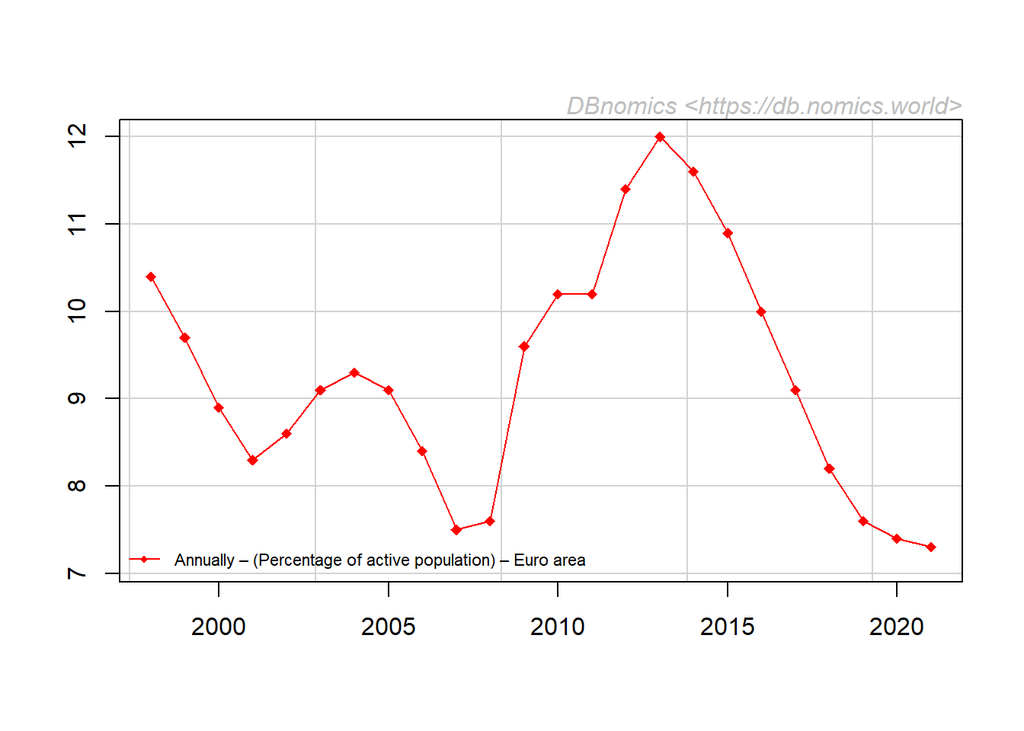

## 4.2 Fetch two values of one dimension from dataset ‘Unemployment rate’ (ZUTN) of AMECO provider

```r
df <- rdb("AMECO", "ZUTN", dimensions = list(geo = c("ea19", "dnk")))
df <- df[!is.na(value))]
# or
# df <- rdb("AMECO", "ZUTN", dimensions = '{"geo": ["ea19", "dnk"]}')
# df <- df[!is.na(value))]
```

```
##    provider_code dataset_code        dataset_name      series_code
## 1:         AMECO         ZUTN Unemployment rat... DNK.1.0.0.0.ZUTN
## 2:         AMECO         ZUTN Unemployment rat... DNK.1.0.0.0.ZUTN
## 3:         AMECO         ZUTN Unemployment rat... DNK.1.0.0.0.ZUTN
## 4:         AMECO         ZUTN Unemployment rat... DNK.1.0.0.0.ZUTN
## 5:         AMECO         ZUTN Unemployment rat... DNK.1.0.0.0.ZUTN
## 6:         AMECO         ZUTN Unemployment rat... DNK.1.0.0.0.ZUTN
##            series_name original_period     period original_value value
## 1: Annually – (Perc...            1960 1960-01-01              2   2.0
## 2: Annually – (Perc...            1961 1961-01-01            1.6   1.6
## 3: Annually – (Perc...            1962 1962-01-01            1.4   1.4
## 4: Annually – (Perc...            1963 1963-01-01              2   2.0
## 5: Annually – (Perc...            1964 1964-01-01            1.2   1.2
## 6: Annually – (Perc...            1965 1965-01-01            0.9   0.9
##    @frequency                unit                Unit geo Country freq
## 1:     annual percentage-of-ac... (Percentage of a... dnk Denmark    a
## 2:     annual percentage-of-ac... (Percentage of a... dnk Denmark    a
## 3:     annual percentage-of-ac... (Percentage of a... dnk Denmark    a
## 4:     annual percentage-of-ac... (Percentage of a... dnk Denmark    a
## 5:     annual percentage-of-ac... (Percentage of a... dnk Denmark    a
## 6:     annual percentage-of-ac... (Percentage of a... dnk Denmark    a
##    Frequency          indexed_at
## 1:  Annually 2019-11-08 16:33:50
## 2:  Annually 2019-11-08 16:33:50
## 3:  Annually 2019-11-08 16:33:50
## 4:  Annually 2019-11-08 16:33:50
## 5:  Annually 2019-11-08 16:33:50
## 6:  Annually 2019-11-08 16:33:50
```

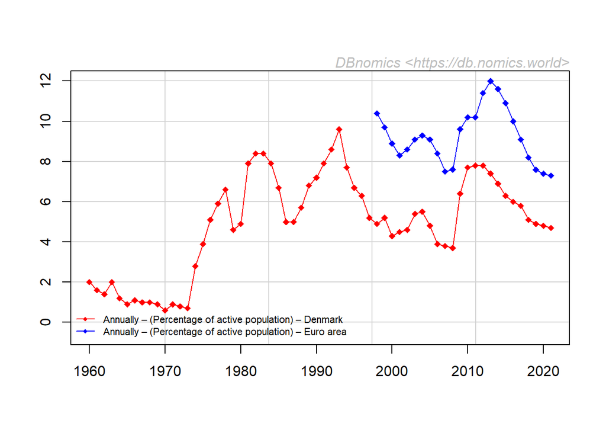

## 4.3 Fetch several values of several dimensions from dataset ‘Doing business’ (DB) of World Bank

```r
df <- rdb("WB", "DB", dimensions = list(country = c("DZ", "PE"), indicator = c("ENF.CONT.COEN.COST.ZS", "IC.REG.COST.PC.FE.ZS")))
df <- df[!is.na(value))]
# or
# df <- rdb("WB", "DB", dimensions = '{"country": ["DZ", "PE"], "indicator": ["ENF.CONT.COEN.COST.ZS", "IC.REG.COST.PC.FE.ZS"]}')
# df <- df[!is.na(value))]
```

```
##    provider_code dataset_code   dataset_name         series_code
## 1:            WB           DB Doing Business IC.REG.COST.PC.F...
## 2:            WB           DB Doing Business IC.REG.COST.PC.F...
## 3:            WB           DB Doing Business IC.REG.COST.PC.F...
## 4:            WB           DB Doing Business IC.REG.COST.PC.F...
## 5:            WB           DB Doing Business IC.REG.COST.PC.F...
## 6:            WB           DB Doing Business IC.REG.COST.PC.F...
##            series_name original_period     period original_value value
## 1: Cost of business...            2003 2003-01-01           16.3  16.3
## 2: Cost of business...            2004 2004-01-01           14.6  14.6
## 3: Cost of business...            2005 2005-01-01           12.4  12.4
## 4: Cost of business...            2006 2006-01-01           13.4  13.4
## 5: Cost of business...            2007 2007-01-01           13.2  13.2
## 6: Cost of business...            2008 2008-01-01           10.8  10.8
##    @frequency country Country          indexed_at           indicator
## 1:     annual      DZ Algeria 2020-03-11 14:09:09 IC.REG.COST.PC.F...
## 2:     annual      DZ Algeria 2020-03-11 14:09:09 IC.REG.COST.PC.F...
## 3:     annual      DZ Algeria 2020-03-11 14:09:09 IC.REG.COST.PC.F...
## 4:     annual      DZ Algeria 2020-03-11 14:09:09 IC.REG.COST.PC.F...
## 5:     annual      DZ Algeria 2020-03-11 14:09:09 IC.REG.COST.PC.F...
## 6:     annual      DZ Algeria 2020-03-11 14:09:09 IC.REG.COST.PC.F...
##              Indicator observations_attributes
## 1: Cost of business...              ATTRIBUTE,
## 2: Cost of business...              ATTRIBUTE,
## 3: Cost of business...              ATTRIBUTE,
## 4: Cost of business...              ATTRIBUTE,
## 5: Cost of business...              ATTRIBUTE,
## 6: Cost of business...              ATTRIBUTE,
```

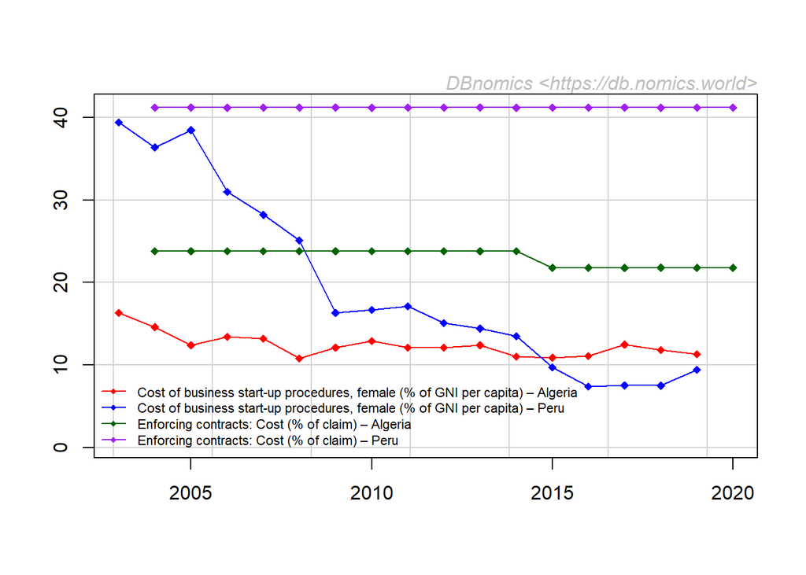

# 5 Fetch time series with a `query`

The query is a Google-like search that will filter/select time series from a provider’s dataset.

## 5.1 Fetch one series from dataset ‘WEO by countries (2019-10 release)’ (WEO:2019-10) of IMF

```r
df <- rdb("IMF", "WEO:2019-10", query = "France current account balance percent")
df <- df[!is.na(value))]
```

```
##    provider_code dataset_code        dataset_name         series_code
## 1:           IMF  WEO:2019-10 WEO by countries... FRA.BCA_NGDPD.pc...
## 2:           IMF  WEO:2019-10 WEO by countries... FRA.BCA_NGDPD.pc...
## 3:           IMF  WEO:2019-10 WEO by countries... FRA.BCA_NGDPD.pc...
## 4:           IMF  WEO:2019-10 WEO by countries... FRA.BCA_NGDPD.pc...
## 5:           IMF  WEO:2019-10 WEO by countries... FRA.BCA_NGDPD.pc...
## 6:           IMF  WEO:2019-10 WEO by countries... FRA.BCA_NGDPD.pc...
##            series_name original_period     period original_value  value
## 1: France – Current...            1980 1980-01-01         -0.595 -0.595
## 2: France – Current...            1981 1981-01-01         -0.771 -0.771
## 3: France – Current...            1982 1982-01-01         -2.062 -2.062
## 4: France – Current...            1983 1983-01-01         -0.838 -0.838
## 5: France – Current...            1984 1984-01-01         -0.142 -0.142
## 6: France – Current...            1985 1985-01-01         -0.063 -0.063
##    @frequency      unit           Unit          indexed_at weo-country
## 1:     annual pcent_gdp Percent of GDP 2020-10-14 14:39:56         FRA
## 2:     annual pcent_gdp Percent of GDP 2020-10-14 14:39:56         FRA
## 3:     annual pcent_gdp Percent of GDP 2020-10-14 14:39:56         FRA
## 4:     annual pcent_gdp Percent of GDP 2020-10-14 14:39:56         FRA
## 5:     annual pcent_gdp Percent of GDP 2020-10-14 14:39:56         FRA
## 6:     annual pcent_gdp Percent of GDP 2020-10-14 14:39:56         FRA
##    weo-subject WEO Country         WEO Subject
## 1:   BCA_NGDPD      France Current account ...
## 2:   BCA_NGDPD      France Current account ...
## 3:   BCA_NGDPD      France Current account ...
## 4:   BCA_NGDPD      France Current account ...
## 5:   BCA_NGDPD      France Current account ...
## 6:   BCA_NGDPD      France Current account ...
```

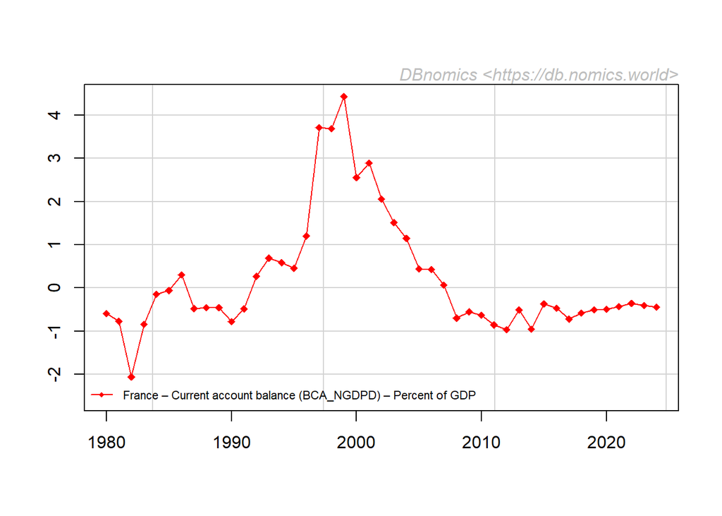

## 5.2 Fetch series from dataset ‘WEO by countries (2019-10 release)’ (WEO:2019-10) of IMF

```r
df <- rdb("IMF", "WEO:2019-10", query = "current account balance percent")
df <- df[!is.na(value))]
```

```
##    provider_code dataset_code        dataset_name         series_code
## 1:           IMF  WEO:2019-10 WEO by countries... DEU.BCA_NGDPD.pc...
## 2:           IMF  WEO:2019-10 WEO by countries... DEU.BCA_NGDPD.pc...
## 3:           IMF  WEO:2019-10 WEO by countries... DEU.BCA_NGDPD.pc...
## 4:           IMF  WEO:2019-10 WEO by countries... DEU.BCA_NGDPD.pc...
## 5:           IMF  WEO:2019-10 WEO by countries... DEU.BCA_NGDPD.pc...
## 6:           IMF  WEO:2019-10 WEO by countries... DEU.BCA_NGDPD.pc...
##            series_name original_period     period original_value  value
## 1: Germany – Curren...            1980 1980-01-01         -1.782 -1.782
## 2: Germany – Curren...            1981 1981-01-01         -0.684 -0.684
## 3: Germany – Curren...            1982 1982-01-01          0.866  0.866
## 4: Germany – Curren...            1983 1983-01-01          0.666  0.666
## 5: Germany – Curren...            1984 1984-01-01          1.423  1.423
## 6: Germany – Curren...            1985 1985-01-01          2.662  2.662
##    @frequency      unit           Unit          indexed_at weo-country
## 1:     annual pcent_gdp Percent of GDP 2020-10-14 14:39:56         DEU
## 2:     annual pcent_gdp Percent of GDP 2020-10-14 14:39:56         DEU
## 3:     annual pcent_gdp Percent of GDP 2020-10-14 14:39:56         DEU
## 4:     annual pcent_gdp Percent of GDP 2020-10-14 14:39:56         DEU
## 5:     annual pcent_gdp Percent of GDP 2020-10-14 14:39:56         DEU
## 6:     annual pcent_gdp Percent of GDP 2020-10-14 14:39:56         DEU
##    weo-subject WEO Country         WEO Subject
## 1:   BCA_NGDPD     Germany Current account ...
## 2:   BCA_NGDPD     Germany Current account ...
## 3:   BCA_NGDPD     Germany Current account ...
## 4:   BCA_NGDPD     Germany Current account ...
## 5:   BCA_NGDPD     Germany Current account ...
## 6:   BCA_NGDPD     Germany Current account ...
```

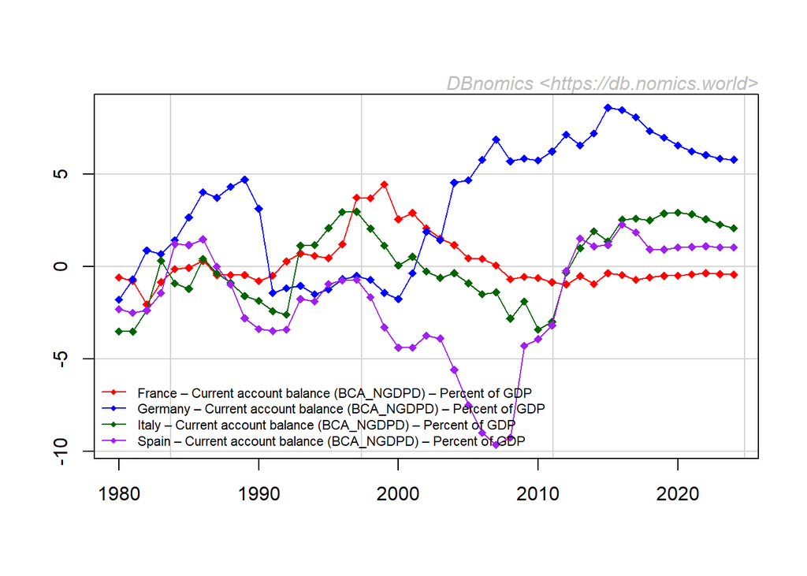

# 6 Fetch time series found on the web site

When you don’t know the codes of the dimensions, provider, dataset or series, you can:

- go to the page of a dataset on [DBnomics website](https://db.nomics.world), for example [Doing Business](https://db.nomics.world/WB/DB),
- select some dimensions by using the input widgets of the left column,

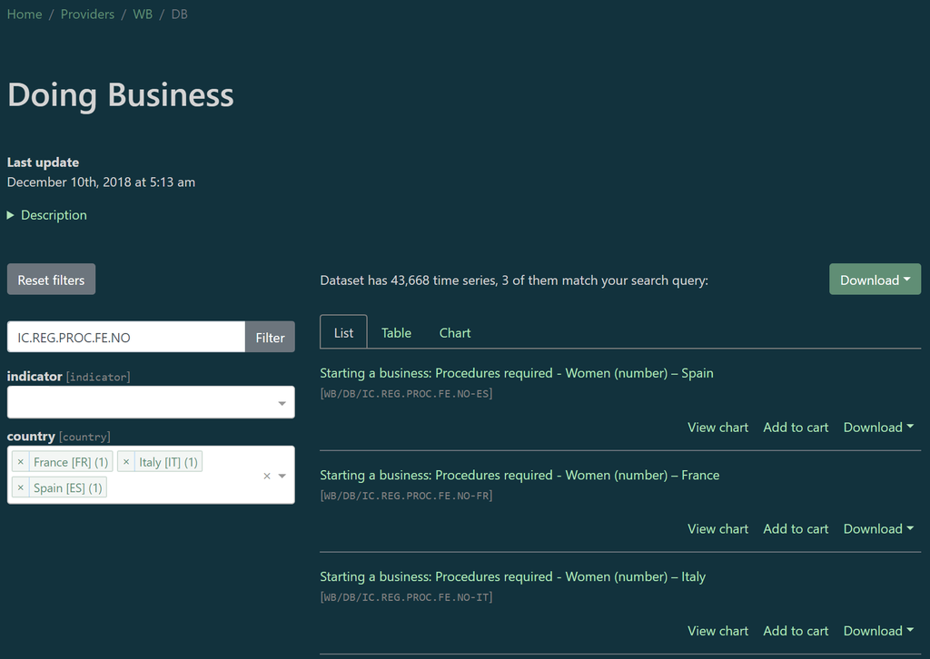

- click on “*Copy API link*” in the menu of the “*Download*” button,

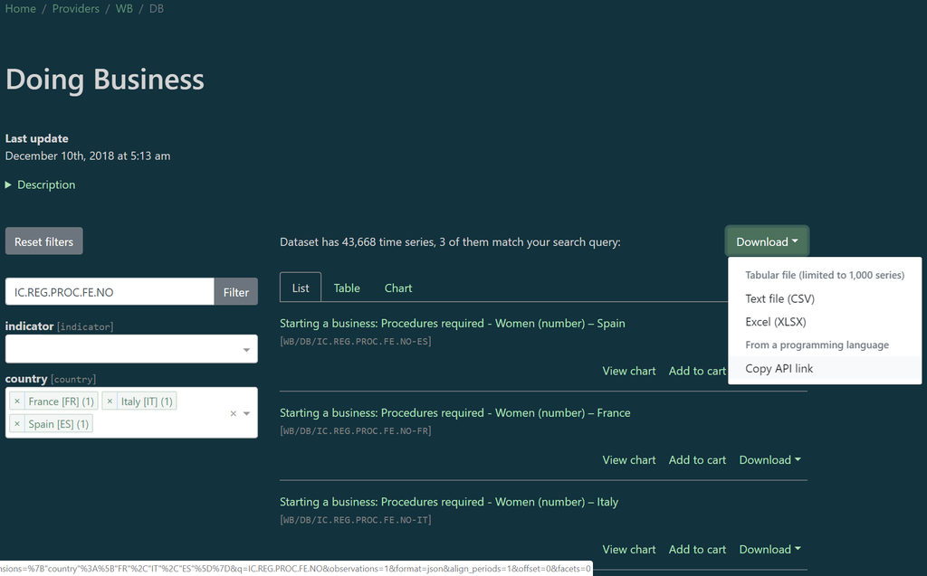

- use the `rdb(api_link = ...)` function such as below.

```r
df <- rdb(api_link = "https://api.db.nomics.world/v22/series/WB/DB?dimensions=%7B%22country%22%3A%5B%22FR%22%2C%22IT%22%2C%22ES%22%5D%7D&q=IC.REG.PROC.FE.NO&observations=1&format=json&align_periods=1&offset=0&facets=0")
df <- df[!is.na(value))]
```

```
##    provider_code dataset_code   dataset_name         series_code
## 1:            WB           DB Doing Business IC.REG.PROC.FE.N...
## 2:            WB           DB Doing Business IC.REG.PROC.FE.N...
## 3:            WB           DB Doing Business IC.REG.PROC.FE.N...
## 4:            WB           DB Doing Business IC.REG.PROC.FE.N...
## 5:            WB           DB Doing Business IC.REG.PROC.FE.N...
## 6:            WB           DB Doing Business IC.REG.PROC.FE.N...
##            series_name original_period     period original_value value
## 1: Starting a busin...            2004 2004-01-01              8     8
## 2: Starting a busin...            2004 2004-01-01             10    10
## 3: Starting a busin...            2004 2004-01-01             10    10
## 4: Starting a busin...            2005 2005-01-01              5     5
## 5: Starting a busin...            2005 2005-01-01             10    10
## 6: Starting a busin...            2005 2005-01-01             10    10
##    @frequency country Country          indexed_at           indicator
## 1:     annual      FR  France 2020-03-11 14:09:09 IC.REG.PROC.FE.N...
## 2:     annual      IT   Italy 2020-03-11 14:09:09 IC.REG.PROC.FE.N...
## 3:     annual      ES   Spain 2020-03-11 14:09:09 IC.REG.PROC.FE.N...
## 4:     annual      FR  France 2020-03-11 14:09:09 IC.REG.PROC.FE.N...
## 5:     annual      IT   Italy 2020-03-11 14:09:09 IC.REG.PROC.FE.N...
## 6:     annual      ES   Spain 2020-03-11 14:09:09 IC.REG.PROC.FE.N...
##              Indicator observations_attributes
## 1: Starting a busin...              ATTRIBUTE,
## 2: Starting a busin...              ATTRIBUTE,
## 3: Starting a busin...              ATTRIBUTE,
## 4: Starting a busin...              ATTRIBUTE,
## 5: Starting a busin...              ATTRIBUTE,
## 6: Starting a busin...              ATTRIBUTE,
```

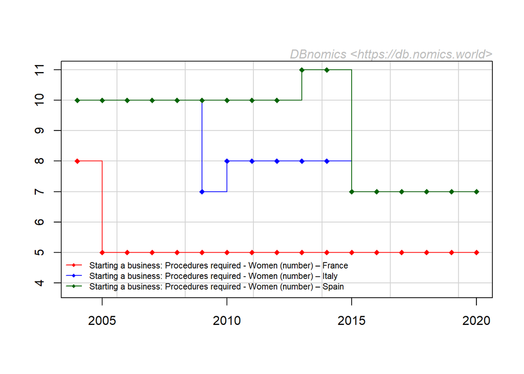

In the event that you only use the argument `api_link`, you can drop the name and run:

```r
df <- rdb("https://api.db.nomics.world/v22/series/WB/DB?dimensions=%7B%22country%22%3A%5B%22FR%22%2C%22IT%22%2C%22ES%22%5D%7D&q=IC.REG.PROC.FE.NO&observations=1&format=json&align_periods=1&offset=0&facets=0")
```

# 7 Fetch time series from the cart

On the cart page of the [DBnomics website](https://db.nomics.world), click on “*Copy API link*” and copy-paste it as an argument of the `rdb(api_link = ...)` function. Please note that when you update your cart, you have to copy this link again, because the link itself contains the ids of the series in the cart.

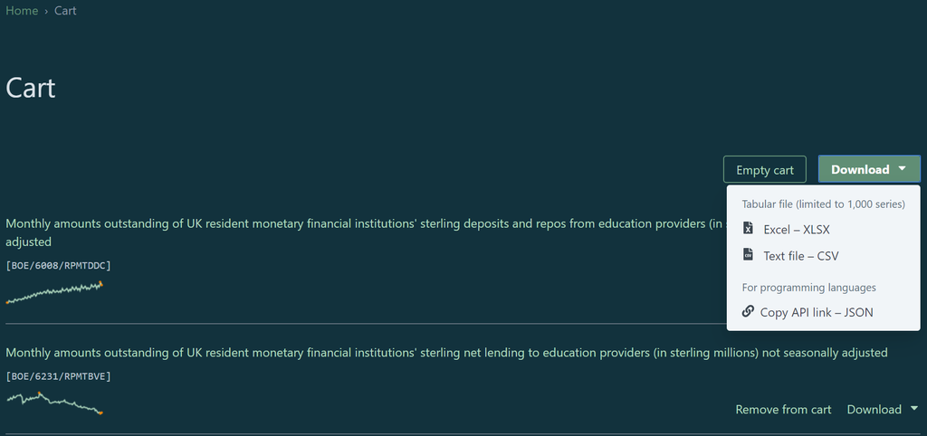

```r
df <- rdb(api_link = "https://api.db.nomics.world/v22/series?observations=1&series_ids=BOE/6008/RPMTDDC,BOE/6231/RPMTBVE")
df <- df[!is.na(value))]
```

```
##    provider_code dataset_code        dataset_name series_code
## 1:           BOE         6008 Industrial analy...     RPMTDDC
## 2:           BOE         6231 Industrial analy...     RPMTBVE
## 3:           BOE         6008 Industrial analy...     RPMTDDC
## 4:           BOE         6231 Industrial analy...     RPMTBVE
## 5:           BOE         6008 Industrial analy...     RPMTDDC
## 6:           BOE         6231 Industrial analy...     RPMTBVE
##            series_name original_period     period original_value value
## 1: Monthly amounts ...         2009-07 2009-07-01          10150 10150
## 2: Monthly amounts ...         2009-07 2009-07-01          11066 11066
## 3: Monthly amounts ...         2009-08 2009-08-01          10400 10400
## 4: Monthly amounts ...         2009-08 2009-08-01          11260 11260
## 5: Monthly amounts ...         2009-09 2009-09-01          11595 11595
## 6: Monthly amounts ...         2009-09 2009-09-01          11208 11208
##    @frequency freq    Freq          indexed_at Instrument Currency
```

[output cut: 27 more lines]

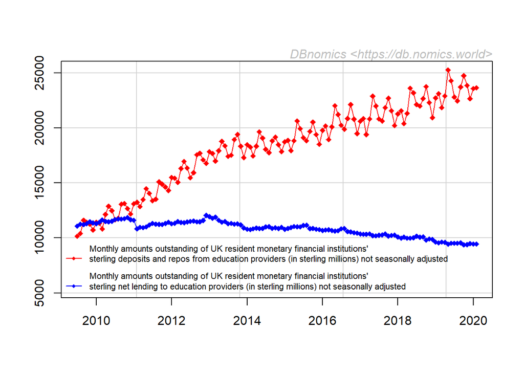

# 8 Fetch the available datasets of a provider

When fetching series from [DBnomics](https://db.nomics.world), you need to give a provider and a dataset before specifying correct dimensions. With the function `rdb_datasets`, you can download the list of the available datasets for a provider.  
For example, to fetch the **IMF** datasets, you have to use:

```r
rdb_datasets(provider_code = "IMF")
```

The result is a named list (its name is **IMF**) with one element which is a `data.table`:

```
## List of 1
##  $ IMF:Classes 'data.table' and 'data.frame':    17 obs. of  2 variables:
##   ..$ code: chr [1:17] "BOP" "BOPAGG" "COMMP" "COMMPP" ...
##   ..$ name: chr [1:17] "Balance of Payments (BOP)" "Balance of Payments (BOP), World and Regional Aggregates" "Primary Commodity Prices" "Primary Commodity Prices Projections" ...
##   ..- attr(*, ".internal.selfref")=<externalptr>
```

With the same function, if you want to fetch the available datasets for multiple providers, you can give a vector of providers and get a named list.

```r
rdb_datasets(provider_code = c("IMF", "BDF"))
```

```
## List of 2
##  $ IMF:Classes 'data.table' and 'data.frame':    17 obs. of  2 variables:
##   ..$ code: chr [1:17] "BOP" "BOPAGG" "COMMP" "COMMPP" ...
##   ..$ name: chr [1:17] "Balance of Payments (BOP)" "Balance of Payments (BOP), World and Regional Aggregates" "Primary Commodity Prices" "Primary Commodity Prices Projections" ...
##   ..- attr(*, ".internal.selfref")=<externalptr>
##  $ BDF:Classes 'data.table' and 'data.frame':    45 obs. of  2 variables:
##   ..$ code: chr [1:45] "AME" "BLS" "BPM6" "BSI" ...
##   ..$ name: chr [1:45] "Macro Economy - Euro Area" "Bank Lending Survey" "Balance of payments- 6th manual" "Monetary Statistics - Euro Area" ...
##   ..- attr(*, ".internal.selfref")=<externalptr>
```

```
## Number of datasets for IMF : 17
## Number of datasets for BDF : 45
```

In the event that you only request the datasets for one provider, if you define `simplify = TRUE`, then the result will be a `data.table` not a named list.

```r
rdb_datasets(provider_code = "IMF", simplify = TRUE)
```

```
##      code                name
## 1:    BOP Balance of Payme...
## 2: BOPAGG Balance of Payme...
## 3:  COMMP Primary Commodit...
## 4: COMMPP Primary Commodit...
## 5:    CPI Consumer Price I...
## 6:   CPIS Coordinated Port...
```

The extent of datasets gathered by [DBnomics](https://db.nomics.world) can be appreciate by using the function with the argument `provider_code` set to `NULL`:

```r
options(rdbnomics.progress_bar_datasets = TRUE)
rdb_datasets()
options(rdbnomics.progress_bar_datasets = FALSE)
```

```
##    Provider Number of datasets
## 1:     AFDB                  1
## 2:    AMECO                481
## 3:      BCB                 85
## 4:    BCEAO                 28
## 5:      BDF                 45
## 6:      BEA                555
```

# 9 Fetch the possible dimensions of available datasets of a provider

When fetching series from [DBnomics](https://db.nomics.world), it can be interesting and especially useful to specify dimensions for a particular dataset to download only the series you want to analyse. With the function `rdb_dimensions`, you can download these dimensions and their meanings.  
For example, for the dataset **WEO:2019-10** of the **IMF**, you may use:

```r
rdb_dimensions(provider_code = "IMF", dataset_code = "WEO:2019-10")
```

The result is a nested named list (its names are **IMF**, **WEO:2019-10** and the dimensions names) with a `data.table` at the end of each branch:

```
## Number of dimensions for IMF/WEO:2019-10 : 3
```

```
##                   unit                Unit
## 1:                 idx               Index
## 2: national_currenc... National currenc...
## 3: national_currenc... National currenc...
## 4:               pcent             Percent
## 5:        pcent_change      Percent change
## 6:           pcent_gdp      Percent of GDP
```

```
##    weo-country         WEO Country
## 1:         ABW               Aruba
## 2:         AFG         Afghanistan
## 3:         AGO              Angola
## 4:         ALB             Albania
## 5:         ARE United Arab Emir...
## 6:         ARG           Argentina
```

```
##    weo-subject         WEO Subject
## 1:         BCA Current account ...
## 2:   BCA_NGDPD Current account ...
## 3:     FLIBOR6 Six-month London...
## 4:         GGR General governme...
## 5:    GGR_NGDP General governme...
## 6:        GGSB General governme...
```

In the event that you only request the dimensions for one dataset for one provider, if you define `simplify = TRUE`, then the result will be a named list `data.table` not a nested named list.

```r
rdb_dimensions(provider_code = "IMF", dataset_code = "WEO:2019-10", simplify = TRUE)
```

```
## List of 3
##  $ unit       :Classes 'data.table' and 'data.frame':    12 obs. of  2 variables:
##   ..$ unit: chr [1:12] "idx" "national_currency" "national_currency_per_current_international_dollar" "pcent" ...
##   ..$ Unit: chr [1:12] "Index" "National currency" "National currency per current international dollar" "Percent" ...
##   ..- attr(*, ".internal.selfref")=<externalptr>
##  $ weo-country:Classes 'data.table' and 'data.frame':    194 obs. of  2 variables:
##   ..$ weo-country: chr [1:194] "ABW" "AFG" "AGO" "ALB" ...
##   ..$ WEO Country: chr [1:194] "Aruba" "Afghanistan" "Angola" "Albania" ...
##   ..- attr(*, ".internal.selfref")=<externalptr>
##  $ weo-subject:Classes 'data.table' and 'data.frame':    45 obs. of  2 variables:
##   ..$ weo-subject: chr [1:45] "BCA" "BCA_NGDPD" "FLIBOR6" "GGR" ...
##   ..$ WEO Subject: chr [1:45] "Current account balance" "Current account balance" "Six-month London interbank offered rate (LIBOR)" "General government revenue" ...
##   ..- attr(*, ".internal.selfref")=<externalptr>
```

```r
options(rdbnomics.progress_bar_datasets = TRUE)
rdb_dimensions()
options(rdbnomics.progress_bar_datasets = FALSE)
```

```
##    Provider Dataset Dimension Number of codes
## 1:     AFDB bbkawjf   country             109
## 2:     AFDB bbkawjf frequency               1
## 3:     AFDB bbkawjf indicator            1279
## 4:     AFDB bbkawjf     scale               1
## 5:     AFDB bbkawjf     units             169
## 6:    AMECO    AAGE      freq               1
```